# coXpress_rat_data

Katie Wang

2024-11-10

```r
library(coXpress)
# BiocManager::install("preprocessCore")
library(preprocessCore)
library(tidyverse)
```

# Running coXpress on the Stemmer et al. rat data

# Step 1: reading data in

This dataset was used in the DiffCoEx analysis. We’re running it in coXpress in order to compare their performance. Downloaded DataSet SOFT File from https://www.ncbi.nlm.nih.gov/sites/GDSbrowser?acc=GDS2901, then extracted from .gz format using 7Zip. Reading in data using code from Additional File 1 of ttps://doi.org/10.1186/1471-2105-11-497

```r
# Session > Set Working Directory > Choose Directory > select the directory that you downloaded this file to

data<-as.matrix(read.csv(file="GDS2901.soft",skip=166,row.names=1,sep="\t",header=T)) # reading in the data
data<-data[-15924,] # remove the last row, which contains no info
```

```r
rawData<-matrix(as.numeric(data[,-1]),nrow=15923) # got rid of the first column, which had gene identifiers
dimnames(rawData)<-dimnames(data[,-1]) # I think this line matches the sample names to their corresponding columns
#we create an annotation matrix containing the matches between probesets and gene names
anno<-as.matrix(data[-2475,1]) # The aforementioned gene identifiers column is saved here, minus the very last element for some reason
normData<-normalize.quantiles(log2(rawData)) # take the log of the data, most likely for better visualization
dimnames(normData)<-dimnames(rawData) # same column names for the normalized data as for the raw data

#we remove the probeset at index 2475 because
#after quantile normalization it has zero variance
#(the probeset has the highest signal of all samples)
normData<-normData[-2475,]
```

The code chunk below shows how the gene expression data was separated into conditions- Eker mutants and wild type. (Analogous to the separation of Golub data into ALL and AML in coXpress_tutorial.Rmd.)

```r
# the code that I referenced from had the matrices transposed (with t()) but coXpress doesn't require the data to be transposed
datC1<-normData[,c(1:12,25:36,37:48)] ### these samples correspond to the Eker mutants.
# Note that since the Eker mutants have two sets of 12 control samples (13:24 and 37:48)
# we discard one to have a symmetric perturbation (carcinogenic vs control) between the two conditions (Eker mutants vs wild-types)
datC2<-normData[,49:84] ###those samples correspond to the wild-types
```

I think that coXpress wants the data to all be in one dataframe, so I will join datC1 and datC2 together by rownames.

```r
datMerged <- merge(datC1, datC2, by=0) # cols 1:36 are Eker mutants, and cols 37:72 are control
datMerged <- datMerged |> # the rownames turned into a column, so I turned them back into a column
  column_to_rownames(var = "Row.names")

# to show that the columns of datMerged are exactly as we expect them to be
#identical(colnames(datMerged[, 1:36]), colnames(datC1))
#identical(colnames(datMerged[, 37:72]), colnames(datC2))
```

## Step 2: cluster data based on a subset of experiments

Cluster on the 36 Eker mutant cases.

```r
# For now, subset datMerged to a smaller number of rows (genes) so that my computer can handle it)
datMergedSmaller <- datMerged[1:2500,]

# Eker cases are in columns 1-36
hc.gene  <- cluster.gene(datMergedSmaller[,1:36],s="pearson",m="average")
```

## Step 3: cut the tree

This choice of cut off is user defined and should be in the range 0 < h < 2. A low value will produce many groups with few genes in each group; a large value will produce few groups with many genes. A height of 0.4 (as used below) equates to pearson correlation of 0.6. I don’t know if this is an appropriate threshold, but this is what was used in the coXpress tutorial, so I will start with that.

```r
g <- cutree(hc.gene, h=0.4)
```

# Step 4: examine the difference between Eker and control samples.

```r
# The control samples are in columns 37-72
#cox <- coXpress(datMerged, g, 1:36, 37:72)
cox <- coXpress(datMergedSmaller, g, 1:36, 37:72)
```

# Step 5: view results.

The results are a data.frame, with one row for each group of genes. See ‘?coXpress’ for a longer explanation of the columns and their meanings.

```r
# Examine the top 30 results
cox[1:30,]
```

```
##      group  N        t1          t2 pr.g1 pr.g2 mean.corr1   mean.corr2
## 988    988  3  14.01991 -3.18545505     0  0.98  0.6663770 -0.186067138
## 28      28  3  87.94184 -3.21471884     0  0.98  0.6929130 -0.116925278
## 490    490  3 152.09265 -1.77161357     0  0.91  0.6203274 -0.169425803
## 40      40  4  24.45863 -2.42395057     0  0.99  0.6313594 -0.147765359
## 282    282  4  38.53598 -2.31071588     0  0.99  0.6244612 -0.138258290
## 148    148  3  19.96529 -0.37946597     0  0.70  0.6846302 -0.066809565
## 461    461  3  33.69194  0.11801315     0  0.48  0.7476231  0.021422941
## 128    128  3  13.81100 -0.88860418     0  0.79  0.6539560 -0.070400618
## 9        9  4  21.84084 -0.15649925     0  0.56  0.6952590 -0.027007619
## 346    346  3  19.05692 -0.96077374     0  0.79  0.6318884 -0.082491583
## 811    811  3  27.61007 -0.60267818     0  0.76  0.6434763 -0.060572289
## 151    151  3  24.55217 -0.28281426     0  0.63  0.6819420 -0.017054265
## 1000  1000  3  28.23106  0.68518158     0  0.35  0.7466792  0.047818340
## 200    200  3  12.27736 -0.38197375     0  0.70  0.6707411 -0.019111182
```

[output cut: 47 more lines]

Some summary stats on N (the number of genes in a given group):

```r
cox |>
  select(N) |>
  summary()
```

```
##        N
##  Min.   : 3.00
##  1st Qu.: 3.00
##  Median : 3.00
##  Mean   : 5.65
##  3rd Qu.: 5.00
##  Max.   :67.00
```

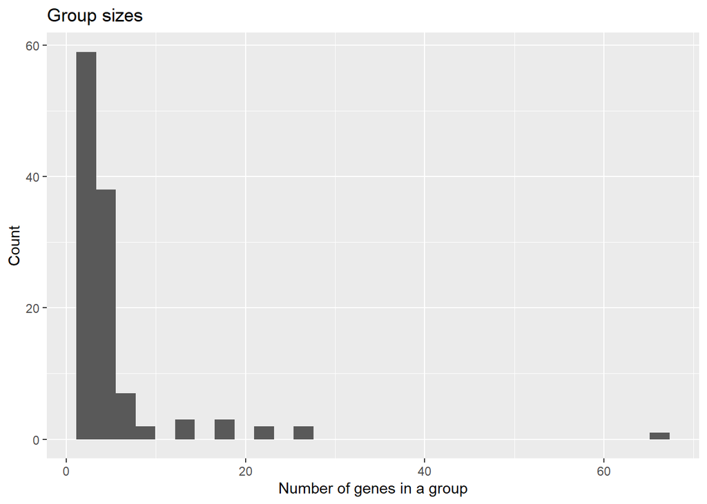

```r
cox |> ggplot() +
  geom_histogram(aes(x=N)) +
  labs(x="Number of genes in a group", y="Count", title = "Group sizes")
```

```r
# Here are the exact numbers from that histogram. There were 59 instances of 3-gene groups, which makes it the largest group by far.
cox_summary <- cox |>
  group_by(N) |>
  summarise(count=n())

cox_summary
```

```
## # A tibble: 13 × 2
##        N count
##    <int> <int>
##  1     3    59
##  2     4    28
##  3     5    10
##  4     6     3
##  5     7     4
##  6     8     2
##  7    14     3
##  8    17     2
##  9    18     1
## 10    22     1
## 11    23     1
## 12    27     2
## 13    67     1
```

When the tree is cut at a height of 0.4, the mean number of genes in a group is 5.65, and the largest group has 67 genes. This is similar to what was observed for the Golub data in the coXpress tutorial.

What percent of the genes examined in this dataset were sorted into modules?

```r
num_grouped <- sum(cox_summary$N * cox_summary$count)
total_genes = nrow(datMergedSmaller)
num_grouped / total_genes
```

```
## [1] 0.2644
```

If we assume that each gene participates in only one module, then 26.44% of genes in this dataset were grouped into a module. This is much lower than the 57.0% observed in the Golub data. However, the coexpression dataframe in this .Rmd was made with a small subset of the rat data, so that could explain the difference.

# Step 6: examine groups of interest graphically

We’ll look at group 211, for which N=14, making it a fairly large group. # look at group 21

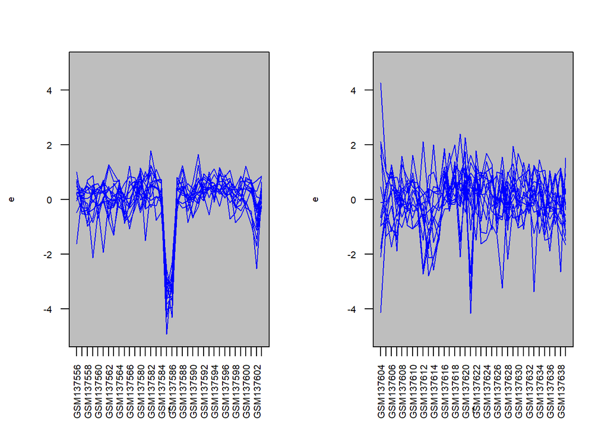

```r
plot.compare.group(datMergedSmaller,g,211,1:36,37:72,
                    scale.center=TRUE,scale.scale=TRUE,
                    ylim=c(-5,5)) # compares Eker mutants (1:36) and control (37:72)
```

```r
# stats on group 211
cox |>
  filter(group==211)
```

```
##   group  N       t1       t2 pr.g1 pr.g2 mean.corr1 mean.corr2 mean.diff
## 1   211 14 71.81407 2.580135     0  0.06  0.7403784 0.06426343  0.676115
```

The genes in group 211 are coexpressed in the Eker mutants (left) but not in the control (right).

```r
# look for groups of genes with N>=5
# that are non-random in group 1 (Eker) and random
# in group 2 (control)
cox[cox$N>=5 & cox$pr.g1<=.05 & cox$pr.g2>=.05, ]
```

```
##     group  N       t1        t2 pr.g1 pr.g2 mean.corr1 mean.corr2 mean.diff
## 211   211 14 71.81407 2.5801346     0  0.06  0.7403784 0.06426343 0.6761150
## 166   166  5 25.71177 0.3188245     0  0.42  0.6588951 0.02836686 0.6305282
## 116   116  5 29.02701 0.8181228     0  0.28  0.6629086 0.05516495 0.6077437
## 76     76  7 38.57875 0.7922460     0  0.23  0.6489282 0.04226820 0.6066600
## 188   188  8 35.16527 1.9695002     0  0.06  0.6646805 0.10153464 0.5631459
```

```r
# now look for groups of genes
# that are random in group 1 (Eker) and non-random
# in group 2 (control)
cox[cox$pr.g1>=.05 & cox$pr.g2<=.05, ]
```

```
## [1] group      N          t1         t2         pr.g1      pr.g2      mean.corr1
## [8] mean.corr2 mean.diff
## <0 rows> (or 0-length row.names)
```

Based on the two tables above, it seems like this subset of the rat data has a few medium-sized modules that are coexpressed in Eker mutants but not in controls, while there are no modules that are coexpressed in only the controls and not in the Eker mutants.

# Step 7: save output to a .txt

This block produces a tab-separated file.

```r
write.table(cox, file="cox_rat.txt", sep="\t", quote=FALSE)
```